# 08 - Ensemble Technique

CWOE (100 members, N = 100, T = 50, c=0.3). Plot the eigenvalue histogram. Apply NSRE technique: Construct a 500 member NSRE by randomly selecting 40 time series. Obtain the eigenvalue histogram for this case.

```python
import numpy as np
import matplotlib.pyplot as plt
import pandas as pd
from scipy.linalg import sqrtm


np.random.seed(0)
```

Ensemble Technique (NSRSE: Non singular random selection ensemble).

We are doing these techniques for singular matrices $(N >> T)$, in which there are only $T$ non zero eigenvalues.

We have the data matrix $A_{N,T}$ (with $N >> T$). Using this single copy of the data matrix, we create an ensemble of matrices. To do it, we select $m$ ($m <= T$) rows randomly (so there are a total of $N C m$ possible selections). For example, let's say we select $m = 38$ rows out of the $N = 211$ possible. After selecting them, we create an ensemble of these matrices.

From these ensemble, we construct the correlation matrices $\frac{1}{T} A A^t$. Therefore, we have an ensemble of many non singular correlation matrices. Therefore, we will have $38$ eigenvalues for each matrix in the ensemble, for a total of $38*500$ eigenvalues

Functions to create the CWOE:

```python
#Function to create the matrix Zeta of dimensions NxT with correlatino c
def matZeta(N,c):
    mat = np.zeros((N,N))
    for i in range(N):
        for j in range(N):
            if i==j:
                mat[i][j]=1
            else:
                mat[i][j]=c
    return(mat)

#Create a matrix of size N,T with random normal entries with mean 0 and std 1
def matA(N,T):
    return(np.random.normal(0,1,(N,T)))

#Create the matrix B, defined as sqrt(Zeta)*A
def matB(N,T,c):
    A = matA(N,T)
    Zeta = matZeta(N,c)

    return(sqrtm(Zeta)@A)

#Create matrix C = 1/T BB^T
def matC(N,T,c):
    B = matB(N,T,c)
    return(1/T*B@ np.transpose(B))

#Create "num" matrices C and get all their eigenvalues
def main(N,T,c,num):
    values = []

    for j in range(num):
        C = matC(N,T,c)
        eigs = np.linalg.eigvals(C)
        for e in eigs:
            values.append(np.real(e))
    return(values)
```

We make the CWOE with 100 members, N = 100 and T = 50, c = 0.3 and plot the eigenvalue histogram

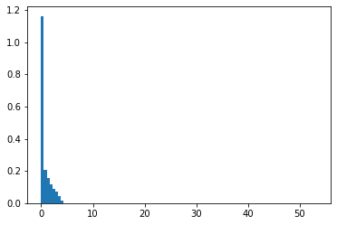

```python
T = 50
N = 100
c = 0.3
num = 100


plt.hist(main(N,T,c,num),bins = 100,density= True);
```

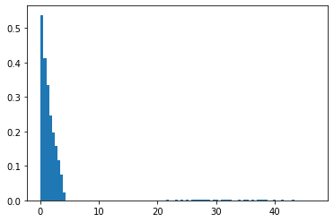

```python
# Most eigenvalues are 0, we can see how those different than 0 distribute:

# If we discard the 0 eigenvalues, the result is:
eigs = [j for j in main(N,T,c,100) if abs(j) > 0.001]


plt.hist(eigs,bins = 100,density= True);
```

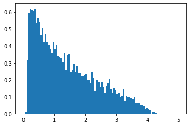

```python
# And if we discard outliers, we have:
plt.hist(eigs,bins = 100,density= True, range=[0,5]);
```